# output

**Ähnlichkeitswerte - Histogramm**  
Histogramm - interval - August 22, 2016

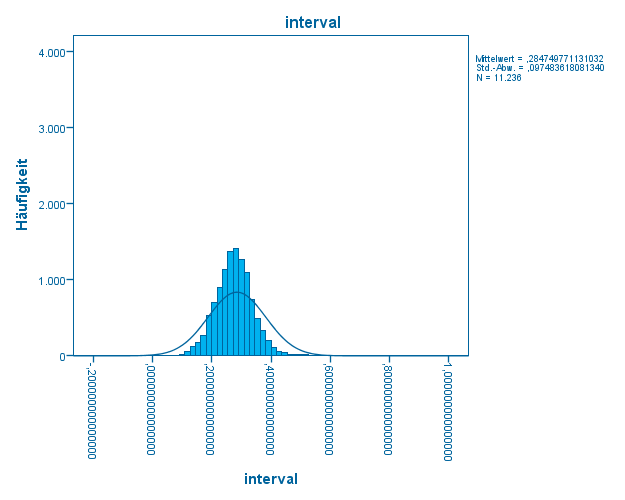


**Ähnlichkeitswerte - Histogramm**  
Histogramm - parson - August 22, 2016

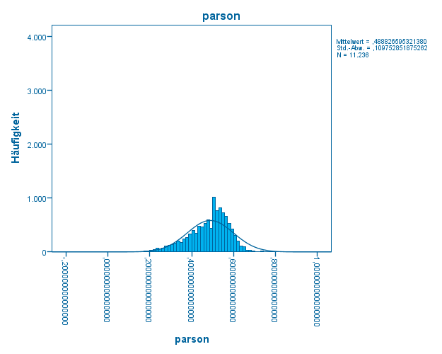


**Ähnlichkeitswerte - Histogramm**  
Histogramm - ju - August 22, 2016

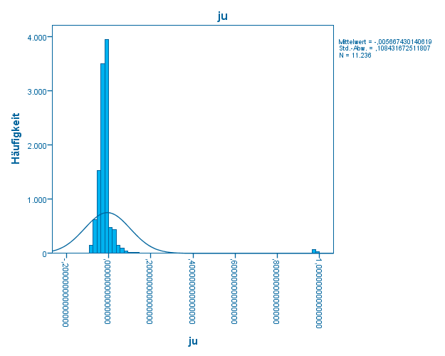


**Paardifferenzen - Häufigkeiten**  
Häufigkeiten - Statistiken - August 22, 2016

StatistikenStatistiken, Tabelle, 1 Stufen von Spaltenüberschriften und 2 Stufen von Zeilenüberschriften, Tabelle mit 6 Spalten und 28 Zeilen

|  |  | ms_ju | gar_ju | interval_ju | parson_ju |
| --- | --- | --- | --- | --- | --- |
| N | Gültig | 11236 | 11236 | 11236 | 11236 |
|  | Fehlend | 0 | 0 | 0 | 0 |
| Mittelwert |  | ,434785057000000 | ,431646008000000 | ,290606580000000 | ,494604886000000 |
| Standardfehler des Mittelwertes |  | ,001397783900000 | ,000837086876000 | ,000475015059000 | ,000851696915000 |
| Median |  | ,454621435000000<sup>a</sup> | ,438505905000000<sup>a</sup> | ,294334977000000<sup>a</sup> | ,514310896000000<sup>a</sup> |
| Modus |  | ,405962641000000 | ,328269927000000<sup>c</sup> | ,278571430000000 | ,513888890000000<sup>c</sup> |
| Standardabweichung |  | ,148165093000000 | ,088731208800000 | ,050351596200000 | ,090279873000000 |
| Varianz |  | ,022 | ,008 | ,003 | ,008 |
| Schiefe |  | -,497 | -1,111 | -1,584 | -1,833 |
| Standardfehler der Schiefe |  | ,023 | ,023 | ,023 | ,023 |
| Kurtosis |  | -,567 | 3,408 | 6,826 | 6,192 |
| Standardfehler der Kurtosis |  | ,046 | ,046 | ,046 | ,046 |
| Spannweite |  | ,752202141000000 | ,662855154000000 | ,477883478000000 | ,746927640000000 |
| Minimum |  | ,003264480000000 | ,003264480000000 | ,003264480000000 | ,003264480000000 |
| Maximum |  | ,755466621000000 | ,666119634000000 | ,481147958000000 | ,750192120000000 |
| Summe |  | 4885,244905000000000 | 4849,974545999999500 | 3265,255533000000000 | 5557,380501000000000 |
| Perzentile | 5 | ,166518146000000<sup>b</sup> | ,292919639000000<sup>b</sup> | ,212386804000000<sup>b</sup> | ,336739472000000<sup>b</sup> |
|  | 10 | ,218056892000000 | ,327255514000000 | ,235632205000000 | ,382254250000000 |
|  | 25 | ,330373592000000 | ,381552777000000 | ,266205583000000 | ,453283793000000 |
|  | 50 | ,454621435000000 | ,438505905000000 | ,294334977000000 | ,514310896000000 |
|  | 75 | ,562687919000000 | ,491514843000000 | ,321462236000000 | ,554890698000000 |
|  | 90 | ,608701036000000 | ,535521106000000 | ,345579278000000 | ,583333333000000 |
|  | 95 | ,626297826000000 | ,558205450000000 | ,361201515000000 | ,599360598000000 |

a. Aus gruppierten Daten berechnet  
b. Perzentile werden aus gruppierten Daten berechnet.  
c. Mehrere Modi vorhanden. Der kleinste Wert wird angezeigt.

**Paardifferenzen - Histogramm**  
Histogramm - ms_ju - August 22, 2016

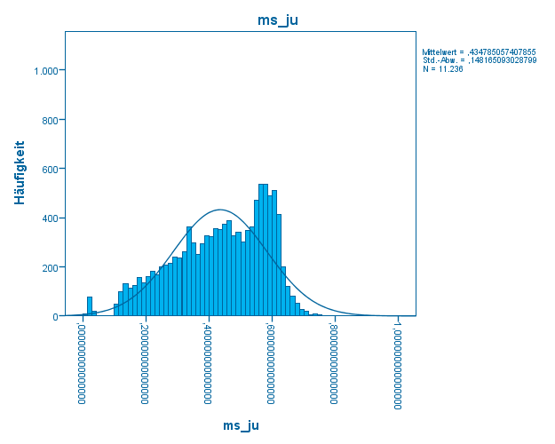